# Practical Machine Learning: Predicting the manner in which exercise-device users did the exercise

Omkar Udipi

20 August 2015

## Executive Summary

The objective of this project is to predict the manner in which exercise-device users did the exercise. This is the “classe” variable in the training set. This project will analyze and determine which variables to predict with. The report will describe how the model is built, cross-validation used, expected out of sample error, and reasons for the decisions made.

## Background

Using exercise devices such as Jawbone Up, Nike FuelBand, and Fitbit, it is now possible to collect a large amount of data about personal activity relatively inexpensively. These type of devices are part of the quantified self movement – a group of enthusiasts who take measurements about themselves regularly to improve their health, to find patterns in their behavior, or because they are tech geeks. One thing that people regularly do is quantify how much of a particular activity they do, but they rarely quantify how well they do it. In this project, the goal will be to use data from accelerometers on the belt, forearm, arm, and dumbell of 6 participants. They were asked to perform barbell lifts correctly and incorrectly in 5 different ways. More information is available from the website here: http://groupware.les.inf.puc-rio.br/har (see the section on the Weight Lifting Exercise Dataset).

## Source Data, R Libraries, Defaults

- Primary source (with thanks): http://groupware.les.inf.puc-rio.br/har
- Training data: https://d396qusza40orc.cloudfront.net/predmachlearn/pml-training.csv
- Test data: https://d396qusza40orc.cloudfront.net/predmachlearn/pml-testing.csv

R Libraries used (if unavailable, please install first):

```r
library(caret)
```

```r
library(rpart)
library(rpart.plot)
library(ggplot2)
library(randomForest)
```

Setting the seed:

```r
set.seed(9090)
```

## Getting the data

```r
trainUrl <- "https://d396qusza40orc.cloudfront.net/predmachlearn/pml-training.csv"
testUrl <- "https://d396qusza40orc.cloudfront.net/predmachlearn/pml-testing.csv"
trainFile <- "pml-training.csv"
testFile <- "pml-testing.csv"

## Commented below to avoid redownloading the file - files have already been downloaded (using MAC OSX)
# download.file(url=trainUrl, destfile = trainFile, method="curl")
# download.file(url=testUrl, destfile = Assignments, method="curl")

training <- read.csv(trainFile, na.strings=c("NA","#DIV/0!",""))
testing <- read.csv(testFile, na.strings=c("NA","#DIV/0!",""))
```

## Tidying the data

### Step 1: Analyzing the data.

Noticed a quite a few near zero values and NAs. First, we will duplicate training data frame into ‘training_filter’. To save space, we will apply each tidy step to ‘training_filter’.

### Step 2: Identify and remove columns with near zero value

```r
NZVtrainingData_position <- nearZeroVar(training,saveMetrics=FALSE)
fig1 <- names(training[c(NZVtrainingData_position)]) # columns having near zero values
training_filter <- training[-c(NZVtrainingData_position)]
```

*Table 1*

```
##  [1] "new_window"             "kurtosis_yaw_belt"
##  [3] "skewness_yaw_belt"      "amplitude_yaw_belt"
##  [5] "avg_roll_arm"           "stddev_roll_arm"
##  [7] "var_roll_arm"           "avg_pitch_arm"
##  [9] "stddev_pitch_arm"       "var_pitch_arm"
## [11] "avg_yaw_arm"            "stddev_yaw_arm"
## [13] "var_yaw_arm"            "max_roll_arm"
## [15] "min_roll_arm"           "min_pitch_arm"
## [17] "amplitude_roll_arm"     "amplitude_pitch_arm"
## [19] "kurtosis_yaw_dumbbell"  "skewness_yaw_dumbbell"
## [21] "amplitude_yaw_dumbbell" "kurtosis_yaw_forearm"
## [23] "skewness_yaw_forearm"   "max_roll_forearm"
## [25] "min_roll_forearm"       "amplitude_roll_forearm"
## [27] "amplitude_yaw_forearm"  "avg_roll_forearm"
## [29] "stddev_roll_forearm"    "var_roll_forearm"
## [31] "avg_pitch_forearm"      "stddev_pitch_forearm"
## [33] "var_pitch_forearm"      "avg_yaw_forearm"
## [35] "stddev_yaw_forearm"     "var_yaw_forearm"
```

### Step 3: Identify and remove columns irrelevant columns

For this project, we will exclude columns  
* which contain timeframes * ‘X’, ‘user_name’, ‘num_window’ because these values are not relevant to predict classe using the sensor readings.

```r
exclude_vars1 <- names(training_filter) %in% c("X","user_name","raw_timestamp_part_1","raw_timestamp_part_2"
                                               ,"cvtd_timestamp","new_window","num_window")
training_filter  <- training_filter[!exclude_vars1]
```

### Step 4: Identify and remove columns with many NA values

This step is fairly manual process and it involves using ‘summary()’ to determine which columns have large NA count. From the analysis, we found there were many similar-looking columns that had many NAs and appear to be covariates produced by the researchers.

```r
exclude_vars2_NA <- grep("^var|^avg|^max|^min|^std|^amplitude|^kurtosis|^skewness",names(training_filter))
fig2 <- summary(training_filter[c(exclude_vars2_NA)]) # column summary of those with many NAs
training_filter <- training_filter[-c(exclude_vars2_NA)]
```

*Figure 2*

```
##  kurtosis_roll_belt kurtosis_picth_belt skewness_roll_belt
##  Min.   :-2.121     Min.   :-2.190      Min.   :-5.745
##  1st Qu.:-1.329     1st Qu.:-1.107      1st Qu.:-0.444
##  Median :-0.899     Median :-0.151      Median : 0.000
##  Mean   :-0.220     Mean   : 4.334      Mean   :-0.026
##  3rd Qu.:-0.219     3rd Qu.: 3.178      3rd Qu.: 0.417
##  Max.   :33.000     Max.   :58.000      Max.   : 3.595
##  NA's   :19226      NA's   :19248       NA's   :19225
##  skewness_roll_belt.1 max_roll_belt     max_picth_belt   max_yaw_belt
##  Min.   :-7.616       Min.   :-94.300   Min.   : 3.00   Min.   :-2.10
##  1st Qu.:-1.114       1st Qu.:-88.000   1st Qu.: 5.00   1st Qu.:-1.30
##  Median :-0.068       Median : -5.100   Median :18.00   Median :-0.90
##  Mean   :-0.296       Mean   : -6.667   Mean   :12.92   Mean   :-0.22
##  3rd Qu.: 0.661       3rd Qu.: 18.500   3rd Qu.:19.00   3rd Qu.:-0.20
##  Max.   : 7.348       Max.   :180.000   Max.   :30.00   Max.   :33.00
##  NA's   :19248        NA's   :19216     NA's   :19216   NA's   :19226
##  min_roll_belt     min_pitch_belt   min_yaw_belt   amplitude_roll_belt
##  Min.   :-180.00   Min.   : 0.00   Min.   :-2.10   Min.   :  0.000
##  1st Qu.: -88.40   1st Qu.: 3.00   1st Qu.:-1.30   1st Qu.:  0.300
##  Median :  -7.85   Median :16.00   Median :-0.90   Median :  1.000
##  Mean   : -10.44   Mean   :10.76   Mean   :-0.22   Mean   :  3.769
##  3rd Qu.:   9.05   3rd Qu.:17.00   3rd Qu.:-0.20   3rd Qu.:  2.083
##  Max.   : 173.00   Max.   :23.00   Max.   :33.00   Max.   :360.000
##  NA's   :19216     NA's   :19216   NA's   :19226   NA's   :19216
##  amplitude_pitch_belt var_total_accel_belt avg_roll_belt
##  Min.   : 0.000       Min.   : 0.000       Min.   :-27.40
##  1st Qu.: 1.000       1st Qu.: 0.100       1st Qu.:  1.10
##  Median : 1.000       Median : 0.200       Median :116.35
##  Mean   : 2.167       Mean   : 0.926       Mean   : 68.06
##  3rd Qu.: 2.000       3rd Qu.: 0.300       3rd Qu.:123.38
##  Max.   :12.000       Max.   :16.500       Max.   :157.40
##  NA's   :19216        NA's   :19216        NA's   :19216
##  stddev_roll_belt var_roll_belt     avg_pitch_belt    stddev_pitch_belt
##  Min.   : 0.000   Min.   :  0.000   Min.   :-51.400   Min.   :0.000
##  1st Qu.: 0.200   1st Qu.:  0.000   1st Qu.:  2.025   1st Qu.:0.200
##  Median : 0.400   Median :  0.100   Median :  5.200   Median :0.400
##  Mean   : 1.337   Mean   :  7.699   Mean   :  0.520   Mean   :0.603
##  3rd Qu.: 0.700   3rd Qu.:  0.500   3rd Qu.: 15.775   3rd Qu.:0.700
##  Max.   :14.200   Max.   :200.700   Max.   : 59.700   Max.   :4.000
##  NA's   :19216    NA's   :19216     NA's   :19216     NA's   :19216
```

[output cut: 97 more lines]

```
##  Min.   :-151.00   Min.   :-1.900   Min.   :-180.00   Min.   :-1.900
##  1st Qu.:   0.00   1st Qu.:-1.400   1st Qu.:-175.00   1st Qu.:-1.400
##  Median : 113.00   Median :-1.100   Median : -61.00   Median :-1.100
##  Mean   :  81.49   Mean   :-0.689   Mean   : -57.57   Mean   :-0.689
##  3rd Qu.: 174.75   3rd Qu.:-0.600   3rd Qu.:   0.00   3rd Qu.:-0.600
##  Max.   : 180.00   Max.   :40.100   Max.   : 167.00   Max.   :40.100
##  NA's   :19216     NA's   :19300    NA's   :19216     NA's   :19300
##  amplitude_pitch_forearm var_accel_forearm
##  Min.   :  0.0           Min.   :  0.000
##  1st Qu.:  2.0           1st Qu.:  6.759
##  Median : 83.7           Median : 21.165
##  Mean   :139.1           Mean   : 33.502
##  3rd Qu.:350.0           3rd Qu.: 51.240
##  Max.   :360.0           Max.   :172.606
##  NA's   :19216           NA's   :19216
```

### Step 5: Identify and remove columns which contain highly correlated variables

This step tries to reduce the number of columns by determining highly correlated pairs (cutoff @75%). When found, we will exclude one of the pair. This would serve to reduce computation on similar correlated and make the training model more efficient.

```r
training_filter_no_class <- training_filter[-c(dim(training_filter))]
exclude_vars3_correlated <- findCorrelation(cor(training_filter_no_class), cutoff= 0.75) # set cutoff at 75%
fig3 <- names(training_filter[c(exclude_vars3_correlated)]) # columns having highly correlated values
training_filter <- training_filter[-c(exclude_vars3_correlated)]
```

*Figure 3*

```
##  [1] "accel_belt_z"      "roll_belt"         "accel_belt_y"
##  [4] "accel_arm_y"       "total_accel_belt"  "accel_dumbbell_z"
##  [7] "accel_belt_x"      "pitch_belt"        "magnet_dumbbell_x"
## [10] "accel_dumbbell_y"  "magnet_dumbbell_y" "accel_arm_x"
## [13] "accel_dumbbell_x"  "accel_arm_z"       "magnet_arm_y"
## [16] "magnet_belt_z"     "accel_forearm_y"   "gyros_forearm_y"
## [19] "gyros_dumbbell_x"  "gyros_dumbbell_z"  "gyros_arm_x"
```

### Review and Replicate to Test dataset

Tidying is completed. Replicate Steps sequentially on test data onto ‘test_filter’. Compare filtered training and test datasets to confirm if column dimensions match. If ok, proceed to train the model using the training set.

```r
test_filter <- testing[-c(NZVtrainingData_position)]
test_filter <- test_filter[!exclude_vars1]
test_filter <- test_filter[-c(exclude_vars2_NA)]
test_filter <- test_filter[-c(exclude_vars3_correlated)]
dim(training_filter); dim(test_filter)
```

```
## [1] 19622    32
```

```
## [1] 20 32
```

## FeaturePlot

Compare classe against all filtered variables (except classe).

*Figure 4* .

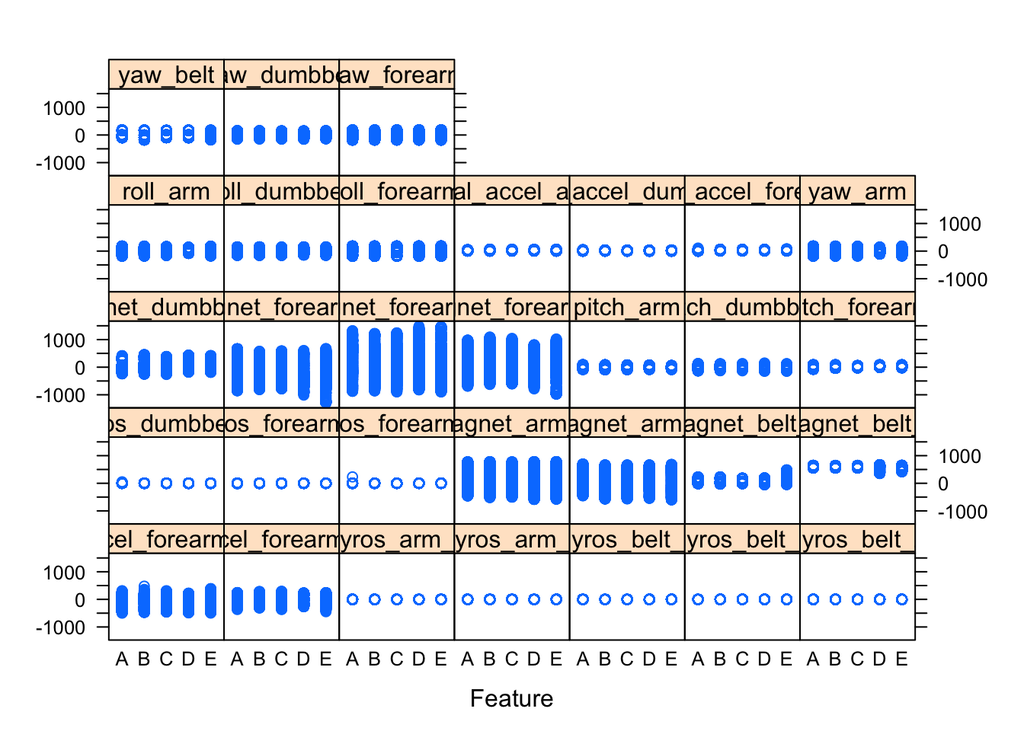

```r
featurePlot(x=training_filter[,-32],y=training_filter[,32])
```

## Cross validation strategy

For this case, we have split the training data into training (75%) and validation (25%) as we have quite a large number of samples.

```r
inTrain <- createDataPartition(y=training_filter$classe, p=0.75, list=FALSE)
trainingData <- training_filter[inTrain, ];
validationData <- training_filter[-inTrain, ]
```

## Train our model using randomforest

```r
classeFit <- randomForest(classe ~. , data=trainingData)
```

## Predict using Validation Data

Predict using our randomforest model using our validation data and compare the predicted values against the validation data’s actual classe values.

```r
predFitTrain <- predict(classeFit,validationData[,-32], type = "class")
fig5 <- confusionMatrix(predFitTrain, validationData$classe)
```

*Figure 5*

```
## Confusion Matrix and Statistics
##
##           Reference
## Prediction    A    B    C    D    E
##          A 1393    0    0    0    0
##          B    2  944    4    0    0
##          C    0    4  845    5    3
##          D    0    0    6  799    6
##          E    0    1    0    0  892
##
## Overall Statistics
##
##                Accuracy : 0.9937
##                  95% CI : (0.991, 0.9957)
##     No Information Rate : 0.2845
##     P-Value [Acc > NIR] : < 2.2e-16
##
##                   Kappa : 0.992
##  Mcnemar's Test P-Value : NA
##
## Statistics by Class:
##
##                      Class: A Class: B Class: C Class: D Class: E
## Sensitivity            0.9986   0.9947   0.9883   0.9938   0.9900
## Specificity            1.0000   0.9985   0.9970   0.9971   0.9998
## Pos Pred Value         1.0000   0.9937   0.9860   0.9852   0.9989
## Neg Pred Value         0.9994   0.9987   0.9975   0.9988   0.9978
## Prevalence             0.2845   0.1935   0.1743   0.1639   0.1837
## Detection Rate         0.2841   0.1925   0.1723   0.1629   0.1819
## Detection Prevalence   0.2841   0.1937   0.1748   0.1654   0.1821
## Balanced Accuracy      0.9993   0.9966   0.9927   0.9954   0.9949
```

## Conclusion

Although not perfect as seen in the matrix, RandomForest does give us quite a high accuracy (>99%). The other statistics also look favorable. We will proceed to use this model to predict our Test data.

## Predict using Test Data

Predict using our randomforest model using our Test data and output the predicted test values

```r
predFitTest <- predict(classeFit,test_filter[,-32])
```

*Figure 6*

```
##  1  2  3  4  5  6  7  8  9 10 11 12 13 14 15 16 17 18 19 20
##  B  A  B  A  A  E  D  B  A  A  B  C  B  A  E  E  A  B  B  B
## Levels: A B C D E
```

## Output predicted test values to files for submission

```r
pml_write_files = function(x){
    n = length(x)
    for(i in 1:n){
        filename = paste0("problem_id_",i,".txt")
        write.table(x[i],file=filename,quote=FALSE,row.names=FALSE,col.names=FALSE)
    }
}

pml_write_files(predFitTest)
```